# I. Data Exploration for Project 5 ML

**(Automatic categorization of questions)**

## Contents

1. Loading the data
2. Cleaning and pretreatment
   1. Merging the dataframes and Removing Duplicates on questions Id
   2. Treating the questions tags
   3. Treating the questions title, and body
   4. Tokenize and normalize the questions title and body
      1. Creating a list of stop words
      2. Tokenize and filter the sentences
      3. Normalize the sentences using lemmatizer or stemmer
      4. Further cleaning
   5. Final treatment
      1. Combining title and body into one
      2. Removing rare words in Title_Body that appeared in less than 30 questions
      3. Treatment of the length of Title_Body
      4. Removing duplicates
      5. Checking the final unique words in Tags and in Title_Body
      6. Cleaning iteration on tags and on title_body of the questions
      7. Final construction
         1. Bigram and trigram
         2. Creating length of tags, title, body, and title_body of the questions
         3. Words frequency
   6. Analysis
   7. Dimension reduction and 2D visualisation
      1. Preparing the data
      2. Transforming the title_body using TF-IDF
      3. Performing dimension reduction using t-SNE
      4. Projection on the 2D t-SNE of the questions for each tag
3. Test example
4. Final conclusion
5. Extracting the data

```python
import numpy as np
import pandas as pd
import matplotlib.pyplot as plt
import seaborn as sns
import scipy.stats as st

import nltk
from nltk.tokenize import word_tokenize, RegexpTokenizer
from nltk.tag import pos_tag
from nltk.stem import WordNetLemmatizer, PorterStemmer
from nltk.corpus import wordnet, stopwords

from sklearn.preprocessing import MultiLabelBinarizer
from sklearn.feature_extraction.text import CountVectorizer, TfidfVectorizer
from sklearn.manifold import TSNE

import pickle

import lxml
import html5lib
from bs4 import BeautifulSoup
import re

import spacy
from spacy.tokenizer import Tokenizer
from spacy.lang.en import English

from collections import Counter

from wordcloud import WordCloud

import gensim

import joblib

import math
import time

sns.set()
```

## 1. Loading the data

First I extracted the data from https://data.stackexchange.com/stackoverflow/query/new https://data.stackexchange.com/stackoverflow/query/edit/1737869

I have used these command line for extraction where I specified that we need questions (PostTypeId = 1),  
with a score bigger than 4 and view count bigger than 100 while the question received at least 1 answer  
and that the questions contain at least 5 tags:

SELECT TOP 500000 Id, Title, Body, Tags, Score, ViewCount, AnswerCount  
FROM Posts  
WHERE PostTypeId = 1 AND Score > 4 AND ViewCount > 100  
AND AnswerCount > 0 AND (LEN(Tags) - LEN(REPLACE(Tags, '<', ''))) >= 5

```python
# Loading the data
SO_questions_df_1 = pd.read_csv('data/QueryResults_21_100.csv')
SO_questions_df_2 = pd.read_csv('data/QueryResults_12to20_100.csv')
SO_questions_df_3 = pd.read_csv('data/QueryResults_9to11_100.csv')
SO_questions_df_4 = pd.read_csv('data/QueryResults_7to8_100.csv')
SO_questions_df_5 = pd.read_csv('data/QueryResults_6_100.csv')
SO_questions_df_6 = pd.read_csv('data/QueryResults_5_2000.csv')
SO_questions_df_7 = pd.read_csv('data/QueryResults_5_100to2000.csv')
```

```python
# To display all columns when needed
pd.set_option('display.max_columns', None)


# Function to add infos about the type and null values to .describe function
def df_description(df):
    # General description
    description = df.describe(include='all', datetime_is_numeric=True)

    # Types and content of the columns
    description_type = pd.DataFrame(df.dtypes, columns=['type']).T
    number_null = (df.shape[0] - description.loc['count'].T)
    percent_null = (df.shape[0] - description.loc['count'].T)*100/df.shape[0]
    description_null = pd.DataFrame([number_null, percent_null],
                                    index=['number null', 'percentage null'])

    # Concatenate general, type and null stats
    description = pd.concat([description_type, description_null, description])
    return description
```

## 2. Cleaning and pretreatment

### A. Merging the dataframes and Removing Duplicates on questions Id

```python
# Merging the dataframes
print('The shape of SO_questions_df_1 =', SO_questions_df_1.shape,
      ', of SO_questions_df_2 =', SO_questions_df_2.shape,
      ', of SO_questions_df_3 =', SO_questions_df_3.shape,
      ', of SO_questions_df_4 =', SO_questions_df_4.shape,
      ', of SO_questions_df_5 =', SO_questions_df_5.shape,
      ', of SO_questions_df_6 =', SO_questions_df_6.shape,
      ', and of SO_questions_df_7 =', SO_questions_df_7.shape)
SO_questions_df = pd.DataFrame()
SO_questions_df = pd.concat([SO_questions_df_1, SO_questions_df_2,
                             SO_questions_df_3, SO_questions_df_4,
                             SO_questions_df_5, SO_questions_df_6,
                             SO_questions_df_7],
                            ignore_index=True)
print('After concatenation, the shape of SO_questions_df = {}'
      .format(SO_questions_df.shape))
```

```
The shape of SO_questions_df_1 = (47630, 7) , of SO_questions_df_2 = (46745, 7) , of SO_questions_df_3 = (39634, 7) , of SO_questions_df_4 = (49418, 7) , of SO_questions_df_5 = (38649, 7) , of SO_questions_df_6 = (35194, 7) , and of SO_questions_df_7 = (20494, 7)
After concatenation, the shape of SO_questions_df = (277764, 7)
```

```python
# Removing the duplicated questions Id
cond = SO_questions_df[SO_questions_df.duplicated(subset='Id') == True]
print('The number of duplicate on question Id',
      cond.shape[0])
SO_questions_df.drop(cond.index, inplace=True)
print('After removing those questions, we are left with this number of rows:',
      SO_questions_df.shape[0])
```

```
The number of duplicate on question Id 0
After removing those questions, we are left with this number of rows: 277764
```

```python
df_description(SO_questions_df)
```

|  | Id | Title | Body | Tags | Score | ViewCount | AnswerCount |
| --- | --- | --- | --- | --- | --- | --- | --- |
| type | int64 | object | object | object | int64 | int64 | int64 |
| number null | 0.0 | 0.0 | 0.0 | 0.0 | 0.0 | 0.0 | 0.0 |
| percentage null | 0.0 | 0.0 | 0.0 | 0.0 | 0.0 | 0.0 | 0.0 |
| count | 277764.0 | 277764 | 277764 | 277764 | 277764.0 | 277764.0 | 277764.0 |
| unique | NaN | 277755 | 277764 | 264113 | NaN | NaN | NaN |
| top | NaN | The ObjectContext instance has been disposed a... | <p>I've got a <a href="http://xlinux.nist.gov/... | <javascript><jquery><html><css><twitter-bootst... | NaN | NaN | NaN |
| freq | NaN | 3 | 1 | 163 | NaN | NaN | NaN |
| mean | 27298140.367675 | NaN | NaN | NaN | 21.65506 | 22493.730512 | 3.126643 |
| std | 19384503.610172 | NaN | NaN | NaN | 119.997009 | 91972.315448 | 3.216046 |
| min | 4.0 | NaN | NaN | NaN | 5.0 | 101.0 | 1.0 |
| 25% | 10022178.75 | NaN | NaN | NaN | 6.0 | 2442.0 | 1.0 |
| 50% | 24569960.0 | NaN | NaN | NaN | 8.0 | 6470.5 | 2.0 |
| 75% | 42386004.5 | NaN | NaN | NaN | 15.0 | 17000.25 | 4.0 |
| max | 76070057.0 | NaN | NaN | NaN | 26959.0 | 10863282.0 | 133.0 |

No missing values in all columns, we will proceed to clean the title, body and tags.

### B. Treating the questions tags

```python
# Lower case the tags
SO_questions_df['Tags'] = SO_questions_df['Tags'].apply(lambda x: x.lower().replace('\n', ' '))
```

```python
# Replacing <> in tags
for index in SO_questions_df.index:
    # Replace open and close balise
    SO_questions_df.loc[index, 'Tags'] = SO_questions_df.loc[index, 'Tags'].replace('<', '').replace('>', ' ')

# Delete last space for each row in Tags
SO_questions_df['Tags'] = SO_questions_df['Tags'].str[:-1]
```

```python
# Function that generate a df containing all the words and their frequency
def words_freq_fct(df, column, freq_min):
    words = Counter(word for x in df[column].str.split() for word in set(x))
    words_df = pd.DataFrame()
    words_df[['Word', 'Frequency']] = words.keys(), words.values()
    words_df.sort_values('Frequency', ascending=False, inplace=True)
    print('Number of unique words in {} = {}, while {} words appeared only in {} questions or less.'
          .format(column,
                  words_df.shape[0],
                  words_df[words_df['Frequency'] <= freq_min].shape[0],
                  freq_min))
    words_df = words_df.reset_index(drop=True)
    return words_df
```

```python
Tag_words_df = words_freq_fct(SO_questions_df, 'Tags', 29)
```

```
Number of unique words in Tags = 33910, while 29182 words appeared only in 29 questions or less.
```

We see that we have lot of unique tags whith most of them appearing in less than 30 questions.

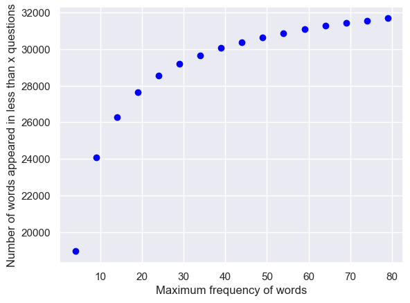

```python
for rare in range(4, 80, 5):
    plt.plot(rare, Tag_words_df[Tag_words_df['Frequency'] <= rare].shape[0],
             c='blue', marker='o', markerfacecolor='blue')
plt.xlabel('Maximum frequency of words')
plt.ylabel('Number of words appeared in less than x questions')
plt.show()
```

It seems that after max frequency of 29, the changes in number of words become linear. We are going to take the value of 29 as optimal to reduce the tags vocabulary from the rare tags that appeared in less than 29 questions.

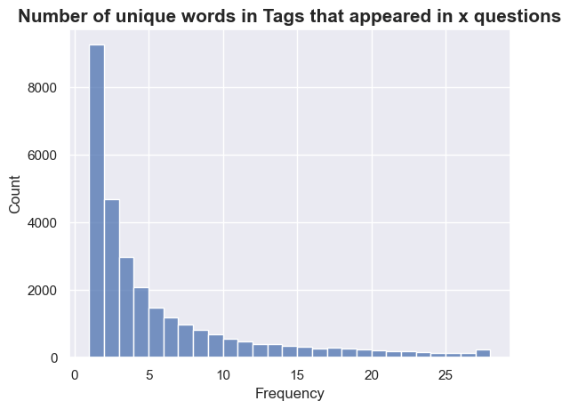

```python
sns.histplot(data=Tag_words_df[Tag_words_df['Frequency'] < 29],
             x='Frequency', binwidth=1)
plt.title('Number of unique words in Tags that appeared in x questions',
          fontsize=15, fontweight='bold')
plt.show()
```

Again, we see that we have lot of tags with low frequency, let's proceed to removing them (all rare words appearing in less than 30 questions).

```python
# Remove the rare words that appeared less than 29 times in tags
c = Counter(word for x in SO_questions_df['Tags'].str.split() for word in set(x))
SO_questions_df['Tags_30'] = [' '.join(y for y in x if c[y] >= 30)
                              for x in SO_questions_df['Tags'].str.split()]
```

```python
# Creating a columns indicating the length of Tags
SO_questions_df['length_Tags_30'] = SO_questions_df['Tags_30'].apply(lambda x: len(x.split(' ')))
```

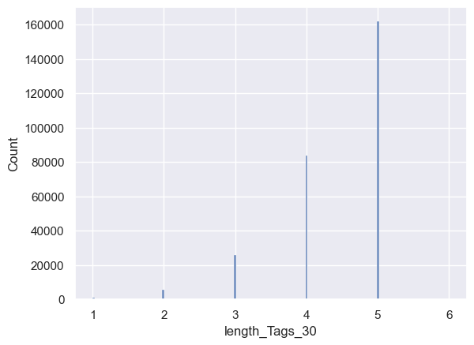

```python
sns.histplot(data=SO_questions_df, x='length_Tags_30')
plt.show()
```

Removing the rare tags have affected the number of tags in some questions. We will proceed and remove all questions with 4 tags or less.

```python
# Function that remove the questions length lower than an input parameter length
def length_limit(df, column, length):
    cond = df[df[column] <= length]
    print('The number of questions with {} length of {} or less = {}'
          .format(column, length, cond.shape[0]))
    df.drop(cond.index, inplace=True)
    print('After removing those questions, we are left with this number of rows:',
          df.shape[0])

    # Resetting the index after the cleaning
    df = df.reset_index(drop=True)

    return df
```

```python
SO_questions_df = length_limit(SO_questions_df, 'length_Tags_30', 4)
```

```
The number of questions with length_Tags_30 length of 4 or less = 115768
After removing those questions, we are left with this number of rows: 161996
```

```python
Tag_words_df = words_freq_fct(SO_questions_df, 'Tags_30', 29)
```

```
Number of unique words in Tags_30 = 4728, while 1430 words appeared only in 29 questions or less.
```

We see that number of unique tags have drastically got smaller but we still have some tags appearing in less than 30 questions (due to cleaning the questions with less than 4 tags), we are going to iterate 10 times on cleaning those rare tags and removing the questions with less than 4 tags

```python
def tag_iteration_cleaning(df, column, rare_limit, len_limit):
    # Remove the rare words that appeared less than rare_limit times in tags
    c = Counter(word for x in df[column].str.split() for word in set(x))
    new_tags_col = column + '_' + str(rare_limit)
    df[new_tags_col] = [' '.join(y for y in x if c[y] >= rare_limit)
                        for x in df[column].str.split()]
    # Creating a columns indicating the length of Tags
    length_col = 'length_' + new_tags_col
    df[length_col] = df[new_tags_col].apply(lambda x: len(x.split(' ')))
    # Removing questions with less than len_limit tags
    df = length_limit(df, length_col, len_limit)
    return df
```

```python
for i in range(0, 10):
    print('Iteration', i)
    SO_questions_df = tag_iteration_cleaning(SO_questions_df, 'Tags', 30, 4)
    print()
```

```
Iteration 0
The number of questions with length_Tags_30 length of 4 or less = 27489
After removing those questions, we are left with this number of rows: 134507

Iteration 1
The number of questions with length_Tags_30 length of 4 or less = 8860
After removing those questions, we are left with this number of rows: 125647

Iteration 2
The number of questions with length_Tags_30 length of 4 or less = 3714
After removing those questions, we are left with this number of rows: 121933

Iteration 3
The number of questions with length_Tags_30 length of 4 or less = 1756
After removing those questions, we are left with this number of rows: 120177

Iteration 4
The number of questions with length_Tags_30 length of 4 or less = 900
After removing those questions, we are left with this number of rows: 119277

Iteration 5
The number of questions with length_Tags_30 length of 4 or less = 536
After removing those questions, we are left with this number of rows: 118741

Iteration 6
The number of questions with length_Tags_30 length of 4 or less = 222
After removing those questions, we are left with this number of rows: 118519

Iteration 7
The number of questions with length_Tags_30 length of 4 or less = 29
After removing those questions, we are left with this number of rows: 118490

Iteration 8
The number of questions with length_Tags_30 length of 4 or less = 28
After removing those questions, we are left with this number of rows: 118462

Iteration 9
The number of questions with length_Tags_30 length of 4 or less = 27
After removing those questions, we are left with this number of rows: 118435
```

```python
Tag_words_df = words_freq_fct(SO_questions_df, 'Tags_30', 29)
```

```
Number of unique words in Tags_30 = 2660, while 2 words appeared only in 29 questions or less.
```

We started with number of unique tags of more than 30k tags to less than 3k tags.

### C. Treating the questions title, and body

```python
# Lower case the title, and body
SO_questions_df['Title_filt'] = SO_questions_df['Title'].apply(lambda x: x.lower().replace('\n', ' '))
SO_questions_df['Body_filt'] = SO_questions_df['Body'].apply(lambda x: x.lower().replace('\n', ' '))
```

```python
# Function that will be used for removing the a href links and code tags
def href_code_removing(x):
    BS = BeautifulSoup(x, 'lxml')
    for link in BS.find_all(['a', 'code', 'blockquote']):
        link.decompose()
    return BS.get_text()
```

```python
# Removing the a href links and code tags in body and Title
SO_questions_df['Title_filt'] = SO_questions_df['Title_filt'].apply(lambda x: href_code_removing(x))
SO_questions_df['Body_filt'] = SO_questions_df['Body_filt'].apply(lambda x: href_code_removing(x))
```

```python
for i in SO_questions_df.index:
    # Removing the links without a href in body and title
    SO_questions_df.loc[i, 'Title_filt'] = re.sub(r'http\S+', '',
                                                  SO_questions_df.loc[i, 'Title_filt'],
                                                  flags=re.MULTILINE)
    SO_questions_df.loc[i, 'Body_filt'] = re.sub(r'http\S+', '',
                                                 SO_questions_df.loc[i, 'Body_filt'],
                                                 flags=re.MULTILINE)
    # Remove English contractions
    SO_questions_df.loc[i, 'Title_filt'] = re.sub("\'\w+", '',
                                                  SO_questions_df.loc[i, 'Title_filt'],
                                                  flags=re.MULTILINE)
    SO_questions_df.loc[i, 'Body_filt'] = re.sub("\'\w+", '',
                                                 SO_questions_df.loc[i, 'Body_filt'],
                                                 flags=re.MULTILINE)
    # Remove adverbs (ly)
    SO_questions_df.loc[i, 'Title_filt'] = re.sub(r"\w+ly\b", '',
                                                  SO_questions_df.loc[i, 'Title_filt'],
                                                  flags=re.MULTILINE)
    SO_questions_df.loc[i, 'Body_filt'] = re.sub(r"\w+ly\b", '',
                                                 SO_questions_df.loc[i, 'Body_filt'],
                                                 flags=re.MULTILINE)
    # Remove string of pure float numbers and remove . at the end of string
    SO_questions_df.loc[i, 'Title_filt'] = re.sub("((?<=[a-zA-Z:])+\.+?)|((?<=[\s])+?(\d*\.*)*)", ' ',
                                                 SO_questions_df.loc[i, 'Title_filt'],
                                                 flags=re.MULTILINE)
    SO_questions_df.loc[i, 'Body_filt'] = re.sub("((?<=[a-zA-Z:])+\.+?)|((?<=[\s])+?(\d*\.*)*)", ' ',
                                                 SO_questions_df.loc[i, 'Body_filt'],
                                                 flags=re.MULTILINE)
```

```python
def start_end_char_clean(df, column, Tags):
    # Removing all folder link like c:\ or c:/ etc
    texts = list(df[column])
    c = set(word for x in texts for word in x.split(' ')
            if ((word.startswith("a:") or word.startswith("b:")
                 or word.startswith("c:") or word.startswith("d:")
                 or word.startswith("e:") or word.startswith("f:")
                 or word.startswith("g:") or word.startswith("h:")
                 or word.startswith("file:")
                 or word.startswith(":\\") or word.startswith(":/")
                 or word.startswith("\\") or word.endswith("\\")
                 or word.startswith("/") or word.endswith("/")
                 or word.startswith("./") or word.endswith("/.")
                 or word.startswith("<") or word.endswith(">")
                 or word.startswith("[") or word.endswith("]")
                 or word.startswith("{") or word.endswith("}")
                 or word.startswith("-") or word.endswith("-")
                 or word.startswith("+") or word.startswith("$"))
                and word not in Tags))
    df[column] = [' '.join(y for y in x.split() if y not in c) for x in texts]
    return df[column]
```

```python
start = time.time()

SO_questions_df['Title_filt'] = start_end_char_clean(SO_questions_df, 'Title_filt',
                                                     list(Tag_words_df['Word']))
SO_questions_df['Body_filt'] = start_end_char_clean(SO_questions_df, 'Body_filt',
                                                    list(Tag_words_df['Word']))

stop = time.time()
print('Processing time: {}s\n'.format(np.around((stop-start), 2)))
```

```
Processing time: 106.23s
```

```python
# Creating a column containing both the title and body
SO_questions_df['Title_Body_filt'] = SO_questions_df['Title_filt'] + ' ' + SO_questions_df['Body_filt']
```

```python
Title_words_df = words_freq_fct(SO_questions_df, 'Title_filt', 29)
Body_words_df = words_freq_fct(SO_questions_df, 'Body_filt', 29)
Title_Body_words_df = words_freq_fct(SO_questions_df, 'Title_Body_filt', 29)
```

```
Number of unique words in Title_filt = 59469, while 56316 words appeared only in 29 questions or less.
Number of unique words in Body_filt = 262304, while 251157 words appeared only in 29 questions or less.
Number of unique words in Title_Body_filt = 283397, while 271611 words appeared only in 29 questions or less.
```

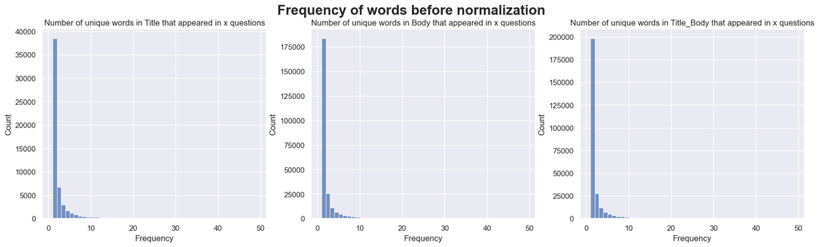

```python
fig, axes = plt.subplots(1, 3, figsize=(20, 5))
sns.histplot(data=Title_words_df[Title_words_df['Frequency'] < 50], x='Frequency',
             binwidth=1, ax=axes[0])
axes[0].set_title('Number of unique words in Title that appeared in x questions')
sns.histplot(data=Body_words_df[Body_words_df['Frequency'] < 50], x='Frequency',
             binwidth=1, ax=axes[1])
axes[1].set_title('Number of unique words in Body that appeared in x questions')
sns.histplot(data=Title_Body_words_df[Title_Body_words_df['Frequency'] < 50], x='Frequency',
             binwidth=1, ax=axes[2])
axes[2].set_title('Number of unique words in Title_Body that appeared in x questions')
plt.suptitle('Frequency of words before normalization', fontsize=20, fontweight='bold')
plt.show()
```

We see that we have lot of unique title_body words with most of them appearing only few times.  
We will treat those rare words after normalizing the text.  
Let's now look at the length of each question title and body.

```python
# Creating a columns indicating the length of unique words in Body_lxml and Title_lxml
SO_questions_df['length_Title_filt'] = SO_questions_df['Title_filt'].apply(lambda x: len(set(x.split(' '))))
SO_questions_df['length_Body_filt'] = SO_questions_df['Body_filt'].apply(lambda x: len(set(x.split(' '))))
SO_questions_df['length_Title_Body_filt'] = SO_questions_df['Title_Body_filt'].apply(lambda x: len(set(x.split(' '))))
```

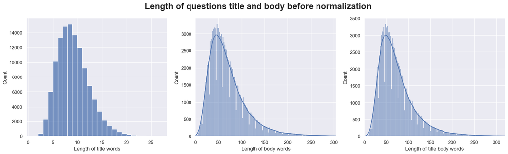

```python
fig, axes = plt.subplots(1, 3, figsize=(20, 5))
sns.histplot(data=SO_questions_df, x='length_Title_filt',
             binwidth=1, ax=axes[0])
axes[0].set_xlabel('Length of title words')
sns.histplot(data=SO_questions_df, x='length_Body_filt',
             kde=True, ax=axes[1])
axes[1].set_xlabel('Length of body words')
axes[1].set_xlim(0, SO_questions_df['length_Body_filt'].median()*5)
sns.histplot(data=SO_questions_df, x='length_Title_Body_filt',
             kde=True, ax=axes[2])
axes[2].set_xlabel('Length of title body words')
axes[2].set_xlim(0, SO_questions_df['length_Title_Body_filt'].median()*5)
plt.suptitle('Length of questions title and body before normalization',
             fontsize=20, fontweight='bold')
plt.show()
```

We see few questions in title_body with length less than 10 words.  
we are going to remove all questions title_body of 9 words or less.

```python
SO_questions_df = length_limit(SO_questions_df, 'length_Title_Body_filt', 9)
```

```
The number of questions with length_Title_Body_filt length of 9 or less = 39
After removing those questions, we are left with this number of rows: 118396
```

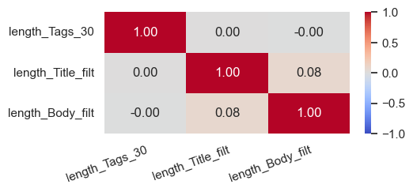

```python
# Correlation between the number of tags, title and body
columns_list = ['length_Tags_30', 'length_Title_filt', 'length_Body_filt']
plt.figure(figsize=(5, 2))
sns.heatmap(SO_questions_df[columns_list].corr(method='pearson'),
            vmin=-1, vmax=1, annot=True, cmap='coolwarm', fmt='0.2f')
plt.xticks(ha='right', rotation=20, rotation_mode='anchor')
plt.show()
```

No correlation between the length of Tags, Title, and Body.

### D. Tokenize and normalize the questions title and body

```python
title = 'c++ .net c# python-10.23.45'
print(title)
print()
print(word_tokenize(title))
print()
print(RegexpTokenizer(r'\S+').tokenize(title))
```

```
c++ .net c# python-10.23.45

['c++', '.net', 'c', '#', 'python-10.23.45']

['c++', '.net', 'c#', 'python-10.23.45']
```

We will be using RegexpTokenizer instead of word_tokenize for tokenizing the title and body.

- First we will tokenize the sentences.
- Second we will filter out the stopwords, adjective and adverbs.
- Third we will Lemmatize or Stem the words.
- Fourth we will clean the sentences from rare words appearing only few times

#### a) Creating a list of stop words

```python
# nltk Stop words
stop_w = list(set(stopwords.words('english'))) + ['etc', 'etc.', 'e.g.', 'i.e.', 'lol',
                                                  'example', 'question', 'thanks', 'thank', 'thx',
                                                  'use', 'using', 'used', 'like', 'liking', 'liked',
                                                  'need', 'needed', 'needing', 'try', 'trying', 'tried',
                                                  'work', 'working', 'worked', 'got', 'getting',
                                                  'want', 'wanted', 'wanting', 'this',
                                                  'contain', 'containing', 'contained']

# spacy stop words
sp = spacy.load('en_core_web_sm')
stop_w = list(set(stop_w + list(sp.Defaults.stop_words)))
print('Length of stop world list = {}'.format(len(stop_w)))
```

```
Length of stop world list = 413
```

```python
# Save the list of stop words
joblib.dump(stop_w, 'data/stop_w.pkl')
```

```
['data/stop_w.pkl']
```

#### b) Tokenize and filter the sentences

```python
# Function that tokenize sentences
def tokenizer_fct(sentence) :
    sentence_clean = sentence.replace('---', '').replace('--', '')\
                             .replace('- ', ' ').replace(' -', ' ')\
                             .replace('...', '').replace('..', '')\
                             .replace('. ', ' ')\
                             .replace('_ ', ' ').replace(' _', ' ')\
                             .replace(' &', ' ').replace('& ', ' ')\
                             .replace('^', ' ')\
                             .replace('?', '').replace('!', '')\
                             .replace(';', ' ').replace(',', ' ')\
                             .replace("'", ' ').replace('"', ' ')\
                             .replace("’", ' ').replace('=', ' ')\
                             .replace(')', ' ').replace('(', ' ')\
                             .replace('|', ' ')\
                             .replace('% ', ' ').replace(' %', ' ')\
                             .replace(' #', ' ').replace('@', ' ')\
                             .replace('*', ' ')\
                             .replace('`', ' ').replace('~', ' ')
    tokenizer = RegexpTokenizer(r'\S+')
    word_tokens = tokenizer.tokenize(sentence_clean)
    return word_tokens


# Stop word filtering
def stop_word_filter_fct(list_words) :
    word_tokens = tokenizer_fct(list_words)
    # Removing all digits and stop words
    filtered_w = [w for w in word_tokens if (not w.isdigit() and not w in stop_w)]
    return filtered_w


# Adjective and adverbe filtering
def adj_adv_word_filter_fct(list_words) :
    word_tokens = stop_word_filter_fct(list_words)
    # Tags of adjective and adverbs
    adj_adv_tags = ['JJR', 'JJS', 'RB', 'RBR', 'RBS', 'WRB']
    # Tagging the words
    tags = dict(pos_tag(word_tokens))
    # Selecting the words tagged adjective and adverbs and not in tags list
    adj_adv_words = [word for word,pos in tags.items() if (pos in adj_adv_tags
                                                           and word not in list(Tag_words_df['Word']))]
    # Removing those words
    filtered_w = [w for w in word_tokens if not w in adj_adv_words]
    return filtered_w
```

```python
start = time.time()

SO_questions_df['Title_filt'] = SO_questions_df['Title_filt'].apply(lambda x: adj_adv_word_filter_fct(x))
SO_questions_df['Body_filt'] = SO_questions_df['Body_filt'].apply(lambda x: adj_adv_word_filter_fct(x))

stop = time.time()
print('Processing time: {}s\n'.format(np.around((stop-start), 2)))
```

```
Processing time: 577.72s
```

#### c) Normalize the sentences using lemmatizer or stemmer

```python
# Lemmatizer
def lem_fct(list_words) :
    lemmatizer = WordNetLemmatizer()
    lem_w = [lemmatizer.lemmatize(w) for w in list_words]
    final_w = ' '.join(lem_w)
    return final_w


# Stemmer
def stem_fct(list_words) :
    stemmer = PorterStemmer()
    stem_w = [stemmer.stem(w) for w in list_words]
    final_w = ' '.join(stem_w)
    return final_w
```

```python
start = time.time()

SO_questions_df['Title_filt_lem'] = SO_questions_df['Title_filt'].apply(lambda x: lem_fct(x))
SO_questions_df['Body_filt_lem'] = SO_questions_df['Body_filt'].apply(lambda x: lem_fct(x))

SO_questions_df['Title_filt_stem'] = SO_questions_df['Title_filt'].apply(lambda x: stem_fct(x))
SO_questions_df['Body_filt_stem'] = SO_questions_df['Body_filt'].apply(lambda x: stem_fct(x))

stop = time.time()
print('Processing time: {}s\n'.format(np.around((stop-start), 2)))
```

```
Processing time: 154.28s
```

#### d) Further cleaning

```python
SO_questions_df['Title_filt_lem'] = start_end_char_clean(SO_questions_df, 'Title_filt_lem',
                                                         list(Tag_words_df['Word']))
SO_questions_df['Title_filt_stem'] = start_end_char_clean(SO_questions_df, 'Title_filt_stem',
                                                          list(Tag_words_df['Word']))
SO_questions_df['Body_filt_lem'] = start_end_char_clean(SO_questions_df, 'Body_filt_lem',
                                                        list(Tag_words_df['Word']))
SO_questions_df['Body_filt_stem'] = start_end_char_clean(SO_questions_df, 'Body_filt_stem',
                                                         list(Tag_words_df['Word']))
```

```python
def final_clean(df, column):
    df[column] = df[column].apply(lambda x: x.replace(':', '')\
                                             .replace('<','')\
                                             .replace('>','')\
                                             .replace('[','')\
                                             .replace(']','')\
                                             .replace('{','')\
                                             .replace('}',''))\
                           .apply(lambda x: ' '.join([w for w in x.split(' ')
                                                      if ((len(w) > 2 and not w.isdigit())
                                                          or w in list(Tag_words_df['Word']))]))
    return df[column]
```

```python
start = time.time()

SO_questions_df['Title_filt_lem'] = final_clean(SO_questions_df, 'Title_filt_lem')
SO_questions_df['Title_filt_stem'] = final_clean(SO_questions_df, 'Title_filt_stem')
SO_questions_df['Body_filt_lem'] = final_clean(SO_questions_df, 'Body_filt_lem')
SO_questions_df['Body_filt_stem'] = final_clean(SO_questions_df, 'Body_filt_stem')

stop = time.time()
print('Processing time: {}s\n'.format(np.around((stop-start), 2)))
```

```
Processing time: 94.41s
```

```python
start = time.time()

for i in SO_questions_df.index:
    # Remove the left over string of pure float numbers
    SO_questions_df.loc[i, 'Title_filt_lem'] = re.sub("((?<=[\s])+?(\d*\.*)*)", '',
                                                      SO_questions_df.loc[i, 'Title_filt_lem'],
                                                      flags=re.MULTILINE)
    SO_questions_df.loc[i, 'Title_filt_stem'] = re.sub("((?<=[\s])+?(\d*\.*)*)", '',
                                                      SO_questions_df.loc[i, 'Title_filt_stem'],
                                                      flags=re.MULTILINE)
    SO_questions_df.loc[i, 'Body_filt_lem'] = re.sub("((?<=[\s])+?(\d*\.*)*)", '',
                                                     SO_questions_df.loc[i, 'Body_filt_lem'],
                                                     flags=re.MULTILINE)
    SO_questions_df.loc[i, 'Body_filt_stem'] = re.sub("((?<=[\s])+?(\d*\.*)*)", '',
                                                     SO_questions_df.loc[i, 'Body_filt_stem'],
                                                     flags=re.MULTILINE)

stop = time.time()
print('Processing time: {}s\n'.format(np.around((stop-start), 2)))
```

```
Processing time: 70.27s
```

### E. Final treatment

```python
column_list = [col for col in SO_questions_df.columns if col not in ['Title_filt', 'Body_filt']]
df_description(SO_questions_df[column_list])
```

|  | Id | Title | Body | Tags | Score | ViewCount | AnswerCount | Tags_30 | length_Tags_30 | Title_Body_filt | length_Title_filt | length_Body_filt | length_Title_Body_filt | Title_filt_lem | Body_filt_lem | Title_filt_stem | Body_filt_stem |
| --- | --- | --- | --- | --- | --- | --- | --- | --- | --- | --- | --- | --- | --- | --- | --- | --- | --- |
| type | int64 | object | object | object | int64 | int64 | int64 | object | int64 | object | int64 | int64 | int64 | object | object | object | object |
| number null | 0.0 | 0.0 | 0.0 | 0.0 | 0.0 | 0.0 | 0.0 | 0.0 | 0.0 | 0.0 | 0.0 | 0.0 | 0.0 | 0.0 | 0.0 | 0.0 | 0.0 |
| percentage null | 0.0 | 0.0 | 0.0 | 0.0 | 0.0 | 0.0 | 0.0 | 0.0 | 0.0 | 0.0 | 0.0 | 0.0 | 0.0 | 0.0 | 0.0 | 0.0 | 0.0 |
| count | 118396.0 | 118396 | 118396 | 118396 | 118396.0 | 118396.0 | 118396.0 | 118396 | 118396.0 | 118396 | 118396.0 | 118396.0 | 118396.0 | 118396 | 118396 | 118396 | 118396 |
| unique | NaN | 118395 | 118396 | 107496 | NaN | NaN | NaN | 107496 | NaN | 118396 | NaN | NaN | NaN | 118064 | 118364 | 118018 | 118364 |
| top | NaN | Pointcut matching methods with annotated param... | <p>How can I display the Wait/Busy Cursor (usu... | javascript jquery html css twitter-bootstrap | NaN | NaN | NaN | javascript jquery html css twitter-bootstrap | NaN | how can i make the cursor turn to the wait cur... | NaN | NaN | NaN |  |  |  |  |
| freq | NaN | 2 | 1 | 163 | NaN | NaN | NaN | 163 | NaN | 1 | NaN | NaN | NaN | 35 | 17 | 37 | 17 |
| mean | 26409455.780001 | NaN | NaN | NaN | 23.371558 | 26074.465506 | 3.324259 | NaN | 5.000008 | NaN | 8.67428 | 70.734003 | 74.169203 | NaN | NaN | NaN | NaN |
| std | 18688050.975293 | NaN | NaN | NaN | 133.908061 | 102335.339063 | 3.376328 | NaN | 0.002906 | NaN | 3.235254 | 43.335357 | 43.000564 | NaN | NaN | NaN | NaN |
| min | 4.0 | NaN | NaN | NaN | 5.0 | 101.0 | 1.0 | NaN | 5.0 | NaN | 1.0 | 1.0 | 10.0 | NaN | NaN | NaN | NaN |
| 25% | 9733965.75 | NaN | NaN | NaN | 6.0 | 2797.0 | 1.0 | NaN | 5.0 | NaN | 6.0 | 42.0 | 45.0 | NaN | NaN | NaN | NaN |
| 50% | 23860135.0 | NaN | NaN | NaN | 9.0 | 7577.0 | 2.0 | NaN | 5.0 | NaN | 8.0 | 61.0 | 64.0 | NaN | NaN | NaN | NaN |
| 75% | 40930012.5 | NaN | NaN | NaN | 16.0 | 20111.0 | 4.0 | NaN | 5.0 | NaN | 11.0 | 88.0 | 91.0 | NaN | NaN | NaN | NaN |
| max | 76020838.0 | NaN | NaN | NaN | 26959.0 | 10068107.0 | 106.0 | NaN | 6.0 | NaN | 27.0 | 708.0 | 711.0 | NaN | NaN | NaN | NaN |

#### a) Combining title and body into one

```python
# Creating columns containing both the title and body
SO_questions_df['Title_Body_filt_lem'] = (SO_questions_df['Title_filt_lem']
                                          + ' '
                                          + SO_questions_df['Body_filt_lem'])

SO_questions_df['Title_Body_filt_stem'] = (SO_questions_df['Title_filt_stem']
                                           + ' '
                                           + SO_questions_df['Body_filt_stem'])

# Creating columns containing the length of title and body
SO_questions_df['length_Title_filt_lem'] = SO_questions_df['Title_filt_lem'].apply(lambda x: len(x.split(' ')))
SO_questions_df['length_Title_filt_stem'] = SO_questions_df['Title_filt_stem'].apply(lambda x: len(x.split(' ')))
SO_questions_df['length_Body_filt_lem'] = SO_questions_df['Body_filt_lem'].apply(lambda x: len(x.split(' ')))
SO_questions_df['length_Body_filt_stem'] = SO_questions_df['Body_filt_stem'].apply(lambda x: len(x.split(' ')))
SO_questions_df['length_Title_Body_filt_lem'] = SO_questions_df['Title_Body_filt_lem'].apply(lambda x: len(x.split(' ')))
SO_questions_df['length_Title_Body_filt_stem'] = SO_questions_df['Title_Body_filt_stem'].apply(lambda x: len(x.split(' ')))
```

#### b) Removing rare words in Title_Body that appeared in less than 30 questions

```python
Title_Body_words_lem_df = words_freq_fct(SO_questions_df, 'Title_Body_filt_lem', 29)
Title_Body_words_stem_df = words_freq_fct(SO_questions_df, 'Title_Body_filt_stem', 29)
```

```
Number of unique words in Title_Body_filt_lem = 145875, while 138896 words appeared only in 29 questions or less.
Number of unique words in Title_Body_filt_stem = 134085, while 128767 words appeared only in 29 questions or less.
```

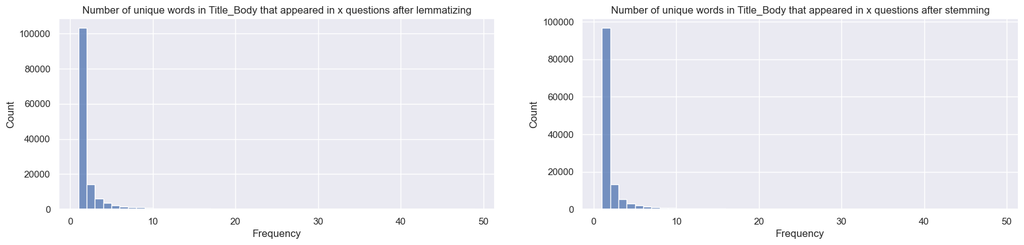

```python
fig, axes = plt.subplots(1, 2, figsize=(20, 4))
sns.histplot(data=Title_Body_words_lem_df[Title_Body_words_lem_df['Frequency'] < 50], x='Frequency',
             binwidth=1, ax=axes[0])
axes[0].set_title('Number of unique words in Title_Body that appeared in x questions after lemmatizing')
sns.histplot(data=Title_Body_words_stem_df[Title_Body_words_stem_df['Frequency'] < 50], x='Frequency',
             binwidth=1, ax=axes[1])
axes[1].set_title('Number of unique words in Title_Body that appeared in x questions after stemming')
plt.show()
```

Lets keep all words that appeared at least in 30 questions.

```python
# Remove the rare words that appeared in 29 questions or less in Title_Body_lem
c = Counter(word for x in SO_questions_df['Title_Body_filt_lem'].str.split() for word in set(x))
SO_questions_df['Title_Body_filt_lem'] = [' '.join(y for y in x if (c[y] >= 30))
                                          for x in SO_questions_df['Title_Body_filt_lem'].str.split()]
SO_questions_df['Title_filt_lem'] = [' '.join(y for y in x if (c[y] >= 30))
                                     for x in SO_questions_df['Title_filt_lem'].str.split()]
SO_questions_df['Body_filt_lem'] = [' '.join(y for y in x if (c[y] >= 30))
                                    for x in SO_questions_df['Body_filt_lem'].str.split()]

# Remove the rare words that appeared in 29 questions or less in Title_Body_stem
c = Counter(word for x in SO_questions_df['Title_Body_filt_stem'].str.split() for word in set(x))
SO_questions_df['Title_Body_filt_stem'] = [' '.join(y for y in x if (c[y] >= 30))
                                           for x in SO_questions_df['Title_Body_filt_stem'].str.split()]
SO_questions_df['Title_filt_stem'] = [' '.join(y for y in x if (c[y] >= 30))
                                      for x in SO_questions_df['Title_filt_stem'].str.split()]
SO_questions_df['Body_filt_stem'] = [' '.join(y for y in x if (c[y] >= 30))
                                     for x in SO_questions_df['Body_filt_stem'].str.split()]
```

#### c) Treatment of the length of Title_Body

We are going to choose questions with at least 10 words in the title_body of the questions

```python
# Creating columns containing the length of tags, title and body
SO_questions_df['length_Tags_30'] = SO_questions_df['Tags_30'].apply(lambda x: len(x.split(' ')))
SO_questions_df['length_Title_filt_lem'] = SO_questions_df['Title_filt_lem'].apply(lambda x: len(x.split(' ')))
SO_questions_df['length_Title_filt_stem'] = SO_questions_df['Title_filt_stem'].apply(lambda x: len(x.split(' ')))
SO_questions_df['length_Body_filt_lem'] = SO_questions_df['Body_filt_lem'].apply(lambda x: len(x.split(' ')))
SO_questions_df['length_Body_filt_stem'] = SO_questions_df['Body_filt_stem'].apply(lambda x: len(x.split(' ')))
SO_questions_df['length_Title_Body_filt_lem'] = SO_questions_df['Title_Body_filt_lem'].apply(lambda x: len(x.split(' ')))
SO_questions_df['length_Title_Body_filt_stem'] = SO_questions_df['Title_Body_filt_stem'].apply(lambda x: len(x.split(' ')))
```

```python
SO_questions_df = length_limit(SO_questions_df, 'length_Title_Body_filt_lem', 9)
SO_questions_df = length_limit(SO_questions_df, 'length_Title_Body_filt_stem', 9)
```

```
The number of questions with length_Title_Body_filt_lem length of 9 or less = 1754
After removing those questions, we are left with this number of rows: 116642
The number of questions with length_Title_Body_filt_stem length of 9 or less = 27
After removing those questions, we are left with this number of rows: 116615
```

We are going as well to remove all questions in title or in body that have length equal 0

```python
# Function that correct the length of a specific column and remove all questions with no words
def cleaning_0_length(df, column, length_column):

    # Correcting the length of title and body with 0 when the == ''
    index_for_0 = df[df[column] == ''].index
    df.loc[index_for_0, length_column] = df.loc[index_for_0, length_column].replace(1, 0)
    print('Number of questions with 0 length =', df[df[length_column] == 0].shape[0])

    # Dropping those questions
    df.drop(index_for_0, inplace=True)
    print('After removing those questions, we are left with these number of rows:', df.shape[0])
    return df
```

```python
SO_questions_df = cleaning_0_length(SO_questions_df, 'Title_filt_lem', 'length_Title_filt_lem')
SO_questions_df = cleaning_0_length(SO_questions_df, 'Title_filt_stem', 'length_Title_filt_stem')
SO_questions_df = cleaning_0_length(SO_questions_df, 'Body_filt_lem', 'length_Body_filt_lem')
SO_questions_df = cleaning_0_length(SO_questions_df, 'Body_filt_stem', 'length_Body_filt_stem')
```

```
Number of questions with 0 length = 324
After removing those questions, we are left with these number of rows: 116291
Number of questions with 0 length = 9
After removing those questions, we are left with these number of rows: 116282
Number of questions with 0 length = 1
After removing those questions, we are left with these number of rows: 116281
Number of questions with 0 length = 0
After removing those questions, we are left with these number of rows: 116281
```

#### d) Removing duplicates

We drop duplicates on Title_Body_filt_lem or on Title_Body_filt_stem with lowest score.

```python
for col in ['Title_Body_filt_lem', 'Title_Body_filt_stem']:
    cond = SO_questions_df[SO_questions_df.sort_values('Score', ascending=False)
                           .duplicated(subset=col) == True]
    print('The number of duplicate on question {} = {}'
          .format(col, cond.shape[0]))
    SO_questions_df.drop(cond.index, inplace=True)
    print('After removing those questions, we are left with this number of rows: {}'
          .format(SO_questions_df.shape[0]))
```

```
The number of duplicate on question Title_Body_filt_lem = 0
After removing those questions, we are left with this number of rows: 116281
The number of duplicate on question Title_Body_filt_stem = 0
After removing those questions, we are left with this number of rows: 116281
```

```python
# Resetting the index after the cleaning
SO_questions_df = SO_questions_df.reset_index(drop=True)
```

#### e) Checking the final unique words in Tags and in Title_Body

```python
Tag_words_df = words_freq_fct(SO_questions_df, 'Tags_30', 29)
Title_words_lem_df = words_freq_fct(SO_questions_df, 'Title_Body_filt_lem', 29)
Title_words_stem_df = words_freq_fct(SO_questions_df, 'Title_Body_filt_stem', 29)
```

```
Number of unique words in Tags_30 = 2660, while 37 words appeared only in 29 questions or less.
Number of unique words in Title_Body_filt_lem = 6979, while 21 words appeared only in 29 questions or less.
Number of unique words in Title_Body_filt_stem = 5318, while 23 words appeared only in 29 questions or less.
```

We see that we still have few rare words appearing in less than 30 questions, this is due to to removing the questions with 9 words or less. We are going to make another round of cleaning the rare words and the length of the questions.

#### f) Cleaning iteration on tags and on title_body of the questions

```python
def title_body_iteration_cleaning(df, column, col_1, col_2, rare_limit, len_limit):
    # Remove the rare words that appeared less than rare_limit times in title_body
    c = Counter(word for x in df[column].str.split() for word in set(x))
    df[column] = [' '.join(y for y in x if (c[y] >= rare_limit))
                  for x in df[column].str.split()]
    df[col_1] = [' '.join(y for y in x if (c[y] >= rare_limit))
                 for x in df[col_1].str.split()]
    df[col_2] = [' '.join(y for y in x if (c[y] >= rare_limit))
                 for x in df[col_2].str.split()]
    # Creating a columns indicating the length of column
    length_col = 'length_' + column
    df[length_col] = df[column].apply(lambda x: len(x.split(' ')))
    # Removing questions with less than len_limit words
    df = length_limit(df, length_col, len_limit)
    return df
```

```python
for i in range(0, 5):
    print('Iteration', i)
    # Cleaning tags that appearing in less than 30 questions and removing questions with less than 4 tags
    SO_questions_df = tag_iteration_cleaning(SO_questions_df, 'Tags', 30, 4)
    Tag_words_df = words_freq_fct(SO_questions_df, 'Tags_30', 29)

    # Cleaning words appearing in less than 30 questions in title_body and length of title_body of less than 9 words
    SO_questions_df = title_body_iteration_cleaning(SO_questions_df, 'Title_Body_filt_lem',
                                                    'Title_filt_lem', 'Body_filt_lem',
                                                    30, 9)
    SO_questions_df = title_body_iteration_cleaning(SO_questions_df, 'Title_Body_filt_stem',
                                                    'Title_filt_stem', 'Body_filt_stem',
                                                    30, 9)

    print()
```

```
Iteration 0
The number of questions with length_Tags_30 length of 4 or less = 1030
After removing those questions, we are left with this number of rows: 115251
Number of unique words in Tags_30 = 2623, while 21 words appeared only in 29 questions or less.
The number of questions with length_Title_Body_filt_lem length of 9 or less = 6
After removing those questions, we are left with this number of rows: 115245
The number of questions with length_Title_Body_filt_stem length of 9 or less = 0
After removing those questions, we are left with this number of rows: 115245

Iteration 1
The number of questions with length_Tags_30 length of 4 or less = 560
After removing those questions, we are left with this number of rows: 114685
Number of unique words in Tags_30 = 2602, while 6 words appeared only in 29 questions or less.
The number of questions with length_Title_Body_filt_lem length of 9 or less = 1
After removing those questions, we are left with this number of rows: 114684
The number of questions with length_Title_Body_filt_stem length of 9 or less = 0
After removing those questions, we are left with this number of rows: 114684

Iteration 2
The number of questions with length_Tags_30 length of 4 or less = 150
After removing those questions, we are left with this number of rows: 114534
Number of unique words in Tags_30 = 2596, while 2 words appeared only in 29 questions or less.
The number of questions with length_Title_Body_filt_lem length of 9 or less = 0
After removing those questions, we are left with this number of rows: 114534
The number of questions with length_Title_Body_filt_stem length of 9 or less = 0
After removing those questions, we are left with this number of rows: 114534

Iteration 3
The number of questions with length_Tags_30 length of 4 or less = 58
After removing those questions, we are left with this number of rows: 114476
Number of unique words in Tags_30 = 2594, while 0 words appeared only in 29 questions or less.
The number of questions with length_Title_Body_filt_lem length of 9 or less = 0
After removing those questions, we are left with this number of rows: 114476
The number of questions with length_Title_Body_filt_stem length of 9 or less = 0
After removing those questions, we are left with this number of rows: 114476

Iteration 4
The number of questions with length_Tags_30 length of 4 or less = 0
After removing those questions, we are left with this number of rows: 114476
Number of unique words in Tags_30 = 2594, while 0 words appeared only in 29 questions or less.
The number of questions with length_Title_Body_filt_lem length of 9 or less = 0
After removing those questions, we are left with this number of rows: 114476
The number of questions with length_Title_Body_filt_stem length of 9 or less = 0
After removing those questions, we are left with this number of rows: 114476
```

#### g) Final construction

##### i) Bigram and trigram

```python
SO_questions_df = SO_questions_df.reset_index(drop=True)
```

```python
# Function that create bigram and trigram
def bi_trigram_formation(df, column):
    # A way to have a list of words for each sentence from title_body_filt_lem
    X_sample = list(df[column].str.split())

    # Build the bigram and trigram models (higher threshold fewer phrases)
    bigram = gensim.models.Phrases(X_sample, min_count=30, threshold=300)
    trigram = gensim.models.Phrases(bigram[X_sample], threshold=300)

    # Faster way to get a sentence clubbed as a trigram/bigram
    bigram_mod = gensim.models.phrases.Phraser(bigram)
    trigram_mod = gensim.models.phrases.Phraser(trigram)

    def make_bigrams(texts):
        return [bigram_mod[doc] for doc in texts]

    def make_trigrams(texts):
        return [trigram_mod[bigram_mod[doc]] for doc in texts]

    # Form Bigrams
    X_sample_bigrams = make_bigrams(X_sample)
    X_sample_bigrams_trigrams = make_trigrams(X_sample_bigrams)

    # Saving to df
    df[column + '_bitri'] = [' '.join(x) for x in X_sample_bigrams_trigrams]

    return df
```

```python
SO_questions_df = bi_trigram_formation(SO_questions_df, 'Title_filt_lem')
SO_questions_df = bi_trigram_formation(SO_questions_df, 'Title_filt_stem')
SO_questions_df = bi_trigram_formation(SO_questions_df, 'Body_filt_lem')
SO_questions_df = bi_trigram_formation(SO_questions_df, 'Body_filt_stem')
SO_questions_df = bi_trigram_formation(SO_questions_df, 'Title_Body_filt_lem')
SO_questions_df = bi_trigram_formation(SO_questions_df, 'Title_Body_filt_stem')
```

##### ii) Creating length of tags, title, body, and title_body of the questions

```python
# Creating columns containing the length of tags, title and body
SO_questions_df['length_Tags_30'] = SO_questions_df['Tags_30'].apply(lambda x: len(x.split(' ')))
SO_questions_df['length_Title_filt_lem_bitri'] = SO_questions_df['Title_filt_lem_bitri'].apply(lambda x: len(x.split(' ')))
SO_questions_df['length_Title_filt_stem_bitri'] = SO_questions_df['Title_filt_stem_bitri'].apply(lambda x: len(x.split(' ')))
SO_questions_df['length_Body_filt_lem_bitri'] = SO_questions_df['Body_filt_lem_bitri'].apply(lambda x: len(x.split(' ')))
SO_questions_df['length_Body_filt_stem_bitri'] = SO_questions_df['Body_filt_stem_bitri'].apply(lambda x: len(x.split(' ')))
SO_questions_df['length_Title_Body_filt_lem_bitri'] = SO_questions_df['Title_Body_filt_lem_bitri'].apply(lambda x: len(x.split(' ')))
SO_questions_df['length_Title_Body_filt_stem_bitri'] = SO_questions_df['Title_Body_filt_stem_bitri'].apply(lambda x: len(x.split(' ')))
```

```python
SO_questions_df = cleaning_0_length(SO_questions_df, 'Title_filt_lem_bitri', 'length_Title_filt_lem_bitri')
SO_questions_df = cleaning_0_length(SO_questions_df, 'Title_filt_stem_bitri', 'length_Title_filt_stem_bitri')
SO_questions_df = cleaning_0_length(SO_questions_df, 'Body_filt_lem_bitri', 'length_Body_filt_lem_bitri')
SO_questions_df = cleaning_0_length(SO_questions_df, 'Body_filt_stem_bitri', 'length_Body_filt_stem_bitri')
```

```
Number of questions with 0 length = 8
After removing those questions, we are left with these number of rows: 114468
Number of questions with 0 length = 0
After removing those questions, we are left with these number of rows: 114468
Number of questions with 0 length = 0
After removing those questions, we are left with these number of rows: 114468
Number of questions with 0 length = 0
After removing those questions, we are left with these number of rows: 114468
```

##### iii) Words frequency

```python
Tag_words_df = words_freq_fct(SO_questions_df, 'Tags_30', 29)
Title_words_lem_df = words_freq_fct(SO_questions_df, 'Title_filt_lem_bitri', 29)
Title_words_stem_df = words_freq_fct(SO_questions_df, 'Title_filt_stem_bitri', 29)
Body_words_lem_df = words_freq_fct(SO_questions_df, 'Body_filt_lem_bitri', 29)
Body_words_stem_df = words_freq_fct(SO_questions_df, 'Body_filt_stem_bitri', 29)
Title_Body_words_lem_df = words_freq_fct(SO_questions_df, 'Title_Body_filt_lem_bitri', 29)
Title_Body_words_stem_df = words_freq_fct(SO_questions_df, 'Title_Body_filt_stem_bitri', 29)
```

```
Number of unique words in Tags_30 = 2594, while 0 words appeared only in 29 questions or less.
Number of unique words in Title_filt_lem_bitri = 6392, while 3877 words appeared only in 29 questions or less.
Number of unique words in Title_filt_stem_bitri = 4823, while 2713 words appeared only in 29 questions or less.
Number of unique words in Body_filt_lem_bitri = 7332, while 739 words appeared only in 29 questions or less.
Number of unique words in Body_filt_stem_bitri = 5544, while 546 words appeared only in 29 questions or less.
Number of unique words in Title_Body_filt_lem_bitri = 7383, while 477 words appeared only in 29 questions or less.
Number of unique words in Title_Body_filt_stem_bitri = 5566, while 319 words appeared only in 29 questions or less.
```

We see some words appearing in less than 30 questions due to the bigram and trigram treatment.

### F. Analysis

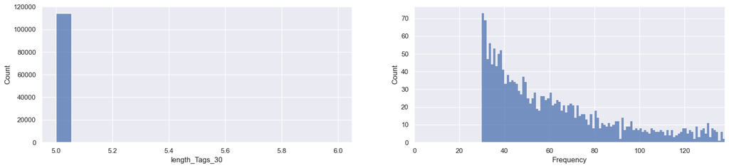

```python
fig, axes = plt.subplots(1, 2, figsize=(20, 4))
sns.histplot(data=SO_questions_df, x='length_Tags_30', ax=axes[0])
sns.histplot(data=Tag_words_df, x='Frequency', binwidth=1, ax=axes[1])
axes[1].set_xlim(0, Tag_words_df['Frequency'].median()*2)
plt.show()
```

All questions have 5 tags and very few questions have 6 tags. Most of the tags appeared in at least 30 questions.

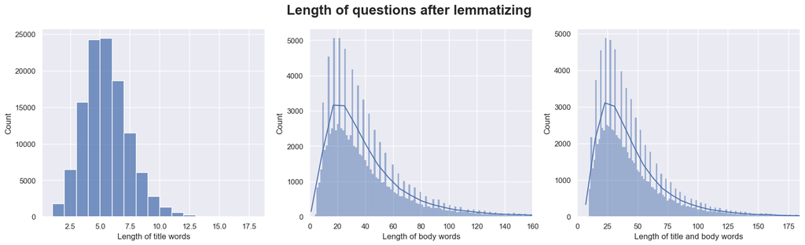

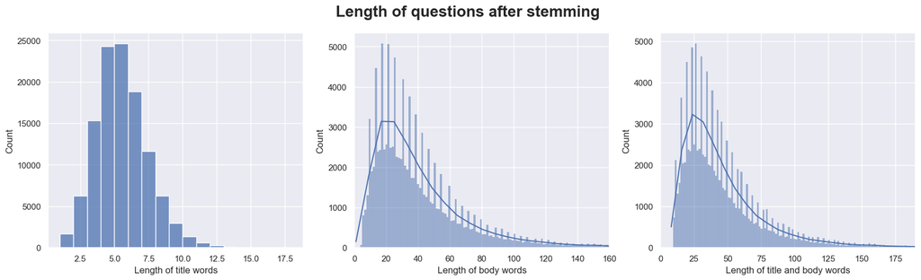

```python
fig, axes = plt.subplots(1, 3, figsize=(20, 5))
sns.histplot(data=SO_questions_df, x='length_Title_filt_lem_bitri',
             binwidth=1, ax=axes[0])
axes[0].set_xlabel('Length of title words')
sns.histplot(data=SO_questions_df, x='length_Body_filt_lem_bitri',
             kde=True, ax=axes[1])
axes[1].set_xlabel('Length of body words')
axes[1].set_xlim(0, SO_questions_df['length_Body_filt_lem_bitri'].median()*5)
sns.histplot(data=SO_questions_df, x='length_Title_Body_filt_lem_bitri',
             kde=True, ax=axes[2])
axes[2].set_xlabel('Length of title and body words')
axes[2].set_xlim(0, SO_questions_df['length_Title_Body_filt_lem_bitri'].median()*5)
plt.suptitle('Length of questions after lemmatizing', fontsize=20, fontweight='bold')
plt.show()

fig, axes = plt.subplots(1, 3, figsize=(20, 5))
sns.histplot(data=SO_questions_df, x='length_Title_filt_stem_bitri',
             binwidth=1, ax=axes[0])
axes[0].set_xlabel('Length of title words')
sns.histplot(data=SO_questions_df, x='length_Body_filt_stem_bitri',
             kde=True, ax=axes[1])
axes[1].set_xlabel('Length of body words')
axes[1].set_xlim(0, SO_questions_df['length_Body_filt_stem_bitri'].median()*5)
sns.histplot(data=SO_questions_df, x='length_Title_Body_filt_stem_bitri',
             kde=True, ax=axes[2])
axes[2].set_xlabel('Length of title and body words')
axes[2].set_xlim(0, SO_questions_df['length_Title_Body_filt_stem_bitri'].median()*5)
plt.suptitle('Length of questions after stemming', fontsize=20, fontweight='bold')
plt.show()
```

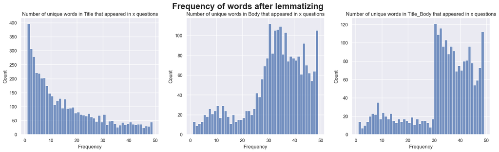

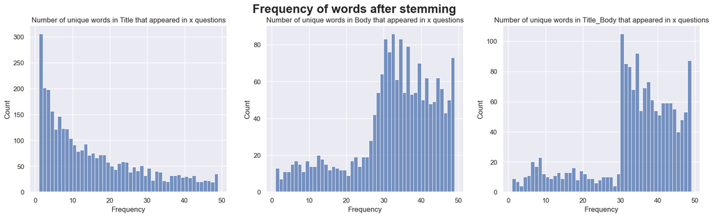

```python
fig, axes = plt.subplots(1, 3, figsize=(20, 5))
sns.histplot(data=Title_words_lem_df[Title_words_lem_df['Frequency'] < 50],
             x='Frequency', binwidth=1, ax=axes[0])
axes[0].set_title('Number of unique words in Title that appeared in x questions')
sns.histplot(data=Body_words_lem_df[Body_words_lem_df['Frequency'] < 50],
             x='Frequency', binwidth=1, ax=axes[1])
axes[1].set_title('Number of unique words in Body that appeared in x questions')
sns.histplot(data=Title_Body_words_lem_df[Title_Body_words_lem_df['Frequency'] < 50],
             x='Frequency', binwidth=1, ax=axes[2])
axes[2].set_title('Number of unique words in Title_Body that appeared in x questions')
plt.suptitle('Frequency of words after lemmatizing', fontsize=20, fontweight='bold')
plt.show()

fig, axes = plt.subplots(1, 3, figsize=(20, 5))
sns.histplot(data=Title_words_stem_df[Title_words_stem_df['Frequency'] < 50],
             x='Frequency', binwidth=1, ax=axes[0])
axes[0].set_title('Number of unique words in Title that appeared in x questions')
sns.histplot(data=Body_words_stem_df[Body_words_stem_df['Frequency'] < 50],
             x='Frequency', binwidth=1, ax=axes[1])
axes[1].set_title('Number of unique words in Body that appeared in x questions')
sns.histplot(data=Title_Body_words_stem_df[Title_Body_words_stem_df['Frequency'] < 50],
             x='Frequency', binwidth=1, ax=axes[2])
axes[2].set_title('Number of unique words in Title_Body that appeared in x questions')
plt.suptitle('Frequency of words after stemming', fontsize=20, fontweight='bold')
plt.show()
```

There are some words appearing in less than 30 questions in title-body of the questions due to creation of bigram and trigram. We don't see much difference between stemmer and lemmatizer in these plots.

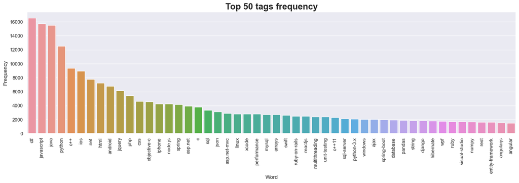

```python
fig = plt.figure(figsize=(20, 5))
sns.barplot(data=Tag_words_df.iloc[0:50, :],
            x='Word',
            y='Frequency')
plt.xticks(rotation=90)
plt.title('Top 50 tags frequency', fontsize=20, fontweight='bold')
plt.show()
```

We see dominance of java, c#, javascript and python as top 4 tags in the dataset.

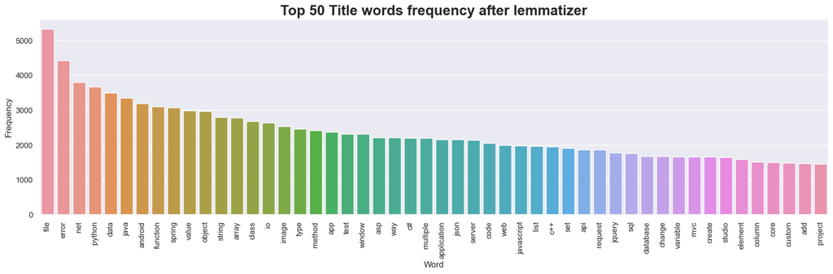

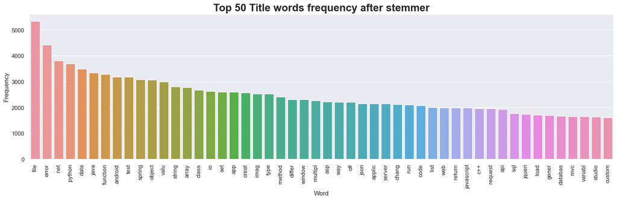

```python
fig = plt.figure(figsize=(20, 5))
sns.barplot(data=Title_words_lem_df.iloc[0:50, :],
            x='Word',
            y='Frequency')
plt.xticks(rotation=90)
plt.title('Top 50 Title words frequency after lemmatizer', fontsize=20, fontweight='bold')
plt.show()

fig = plt.figure(figsize=(20, 5))
sns.barplot(data=Title_words_stem_df.iloc[0:50, :],
            x='Word',
            y='Frequency')
plt.xticks(rotation=90)
plt.title('Top 50 Title words frequency after stemmer', fontsize=20, fontweight='bold')
plt.show()
```

We see some difference between lemmatizer and stemmer in top 50 words in title. We see in stemmer some words got stemmed by removing the last few characters of the word, e.g, valu, creat, applic, chang, imag, databas, etc...

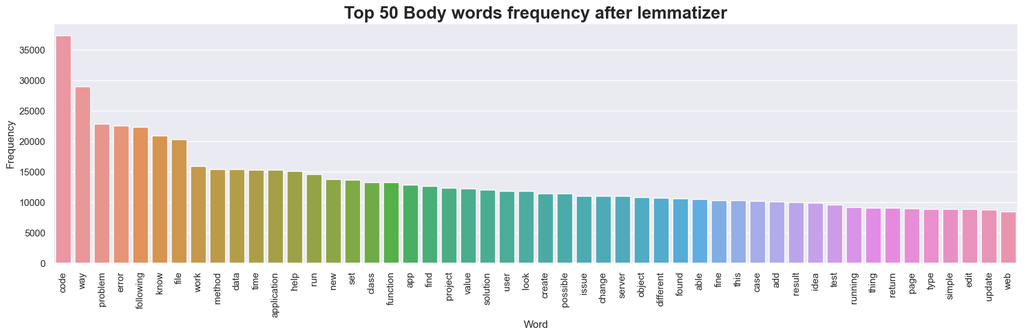

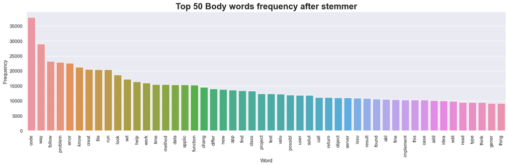

```python
fig = plt.figure(figsize=(20, 5))
sns.barplot(data=Body_words_lem_df.iloc[0:50, :],
            x='Word',
            y='Frequency')
plt.xticks(rotation=90)
plt.title('Top 50 Body words frequency after lemmatizer', fontsize=20, fontweight='bold')
plt.show()

fig = plt.figure(figsize=(20, 5))
sns.barplot(data=Body_words_stem_df.iloc[0:50, :],
            x='Word',
            y='Frequency')
plt.xticks(rotation=90)
plt.title('Top 50 Body words frequency after stemmer', fontsize=20, fontweight='bold')
plt.show()
```

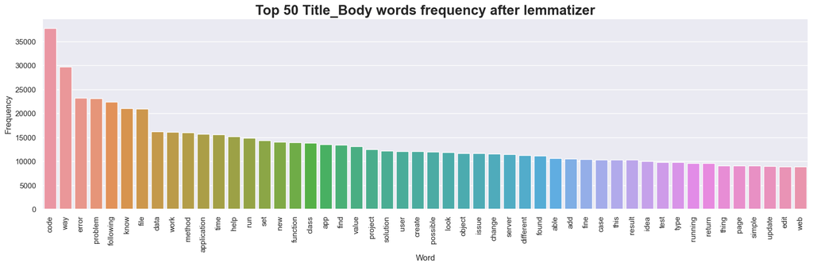

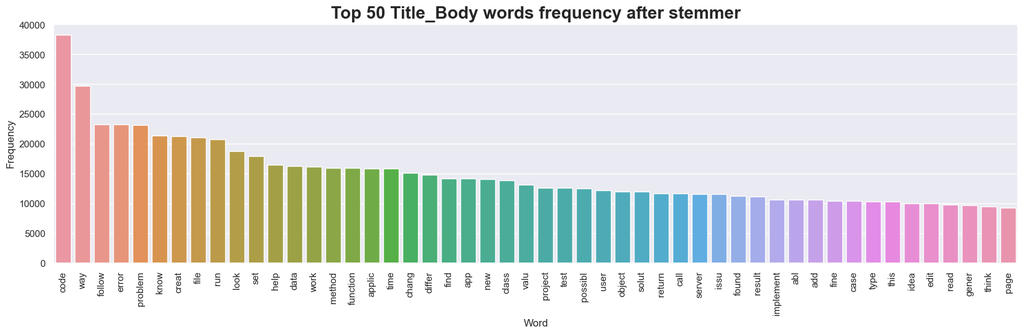

```python
fig = plt.figure(figsize=(20, 5))
sns.barplot(data=Title_Body_words_lem_df.iloc[0:50, :],
            x='Word',
            y='Frequency')
plt.xticks(rotation=90)
plt.title('Top 50 Title_Body words frequency after lemmatizer', fontsize=20, fontweight='bold')
plt.show()

fig = plt.figure(figsize=(20, 5))
sns.barplot(data=Title_Body_words_stem_df.iloc[0:50, :],
            x='Word',
            y='Frequency')
plt.xticks(rotation=90)
plt.title('Top 50 Title_Body words frequency after stemmer', fontsize=20, fontweight='bold')
plt.show()
```

Same comments as for the title and body of the questions for the difference between lemmatizer and stemmer.

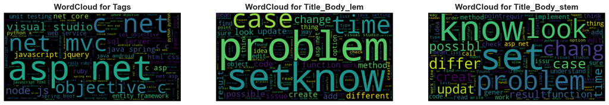

```python
# Apply the wordcloud to the text.
wc_Tags = WordCloud().generate(' '.join(SO_questions_df['Tags_30']))
wc_Title_Body_lem = WordCloud().generate(' '.join(SO_questions_df['Title_Body_filt_lem_bitri']))
wc_Title_Body_stem = WordCloud().generate(' '.join(SO_questions_df['Title_Body_filt_stem_bitri']))

# Plot the generated wordcloud
fig, axes = plt.subplots(1, 3, figsize=(20, 10))
axes[0].imshow(wc_Tags, interpolation='bilinear')
axes[0].axis('off')
axes[0].set_title('WordCloud for Tags', fontsize=15, fontweight='bold')
axes[1].imshow(wc_Title_Body_lem, interpolation='bilinear')
axes[1].axis('off')
axes[1].set_title('WordCloud for Title_Body_lem', fontsize=15, fontweight='bold')
axes[2].imshow(wc_Title_Body_stem, interpolation='bilinear')
axes[2].axis('off')
axes[2].set_title('WordCloud for Title_Body_stem', fontsize=15, fontweight='bold')
plt.show()
```

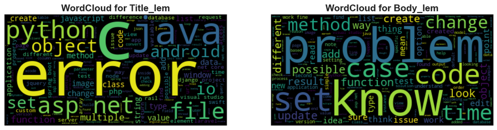

```python
# Apply the wordcloud to the text.
wc_Title_lem = WordCloud().generate(' '.join(str(v) for v in SO_questions_df['Title_filt_lem_bitri']))
wc_Body_lem = WordCloud().generate(' '.join(str(v) for v in SO_questions_df['Body_filt_lem_bitri']))

# Plot the generated wordcloud
fig, axes = plt.subplots(1, 2, figsize=(14, 10))
axes[0].imshow(wc_Title_lem, interpolation='bilinear')
axes[0].axis('off')
axes[0].set_title('WordCloud for Title_lem', fontsize=15, fontweight='bold')
axes[1].imshow(wc_Body_lem, interpolation='bilinear')
axes[1].axis('off')
axes[1].set_title('WordCloud for Body_lem', fontsize=15, fontweight='bold')
plt.show()
```

Comparing the word cloud between the title and the body of the questions shows that the title of the questions contains more useful keywords than the body of the questions.

### G. Dimension reduction and 2D visualisation

```
- Selection of top 25 tags
- TF-IDF the questions title-body (selection of top 250 words in title)
- t-SNE dimension reduction on the questions title-body
- Projection of top 25 tags on the 2D t-SNE
```

#### a) Preparing the data

```python
# Creating dataframe of X_data
X_data_df = pd.DataFrame(SO_questions_df[['Title_filt_lem_bitri', 'Title_Body_filt_lem_bitri']], columns=['Title_filt_lem_bitri', 'Title_Body_filt_lem_bitri'])

# Creating dataframe of Y_target
Y_target_df = pd.DataFrame(SO_questions_df['Tags_30'], columns=['Tags_30'])
```

```python
# Creating a dataframe with the words and frequency of tags
Tag_words_df = words_freq_fct(Y_target_df, 'Tags_30', 29)

# Storing in a list the top 25 tags
top_tags = list(Tag_words_df.loc[:25, 'Word'])
```

```
Number of unique words in Tags_30 = 2594, while 0 words appeared only in 29 questions or less.
```

```
Number of questions with no top_tags = 14109
Size of ytrain after removing the questions with no top_Tags = 100359
```

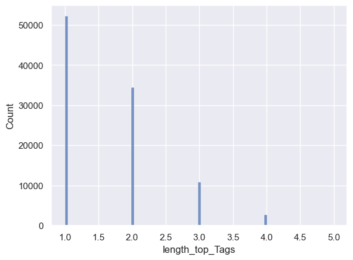

```python
# Create new column with the top tags for each questions in Y_target
Y_target_df['top_Tags'] = [' '.join(y for y in x if y in top_tags) for x in Y_target_df['Tags_30'].str.split(' ')]

# Creating a columns indicating the length of top_Tags
Y_target_df['length_top_Tags'] = Y_target_df['top_Tags'].apply(lambda x: len(x.split(' ')))

# Correcting the 'length_top_Tags' with 0 when the 'top_Tags' == ''
index_for_0 = Y_target_df[Y_target_df['top_Tags'] == ''].index
Y_target_df.loc[index_for_0, 'length_top_Tags'] = Y_target_df.loc[index_for_0, 'length_top_Tags'].replace(1, 0)
print('Number of questions with no top_tags =', Y_target_df[Y_target_df['length_top_Tags'] == 0].shape[0])

# Dropping the questions with no tags from the top_Tags
X_data_df.drop(index_for_0, inplace=True)
Y_target_df.drop(index_for_0, inplace=True)
print('Size of ytrain after removing the questions with no top_Tags =', Y_target_df.shape[0])

sns.histplot(data=Y_target_df, x='length_top_Tags')
plt.show()
```

```python
# Selecting the first tag in each question that will be displayed later in the 2D t-SNE
Y_target_df['1st_Tag'] = [x[0] for x in Y_target_df['top_Tags'].str.split(' ')]
```

```python
# Creating a dataframe with the words and frequency of title
Title_words_df = words_freq_fct(X_data_df, 'Title_filt_lem_bitri', 29)

# Storing in a list the top 250 Title_words
top_Title_words = list(Title_words_df.loc[:250, 'Word'])
```

```
Number of unique words in Title_filt_lem_bitri = 6324, while 4043 words appeared only in 29 questions or less.
```

```
Number of questions with no reduced_Title_Body words = 64
Size of X_data after removing the questions with no reduced_Title_Body words = 100295
```

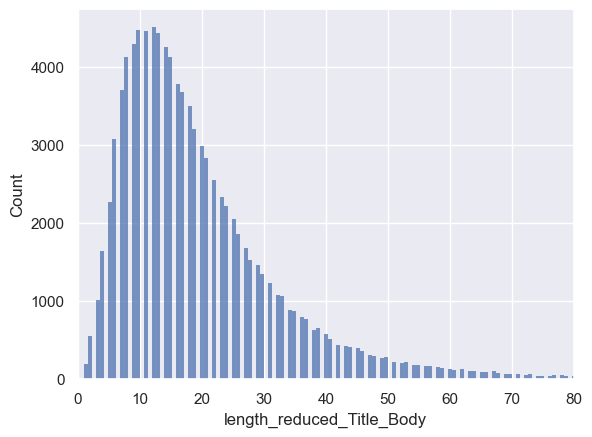

```python
# Create new column with the top Title_Body words for each questions in X_data
X_data_df['reduced_Title_Body'] = [' '.join(y for y in x if y in top_Title_words) for x in X_data_df['Title_Body_filt_lem_bitri'].str.split(' ')]

# Creating a columns indicating the length of reduced_Title_Body
X_data_df['length_reduced_Title_Body'] = X_data_df['reduced_Title_Body'].apply(lambda x: len(x.split(' ')))

# Correcting the 'length_reduced_Title_Body' with 0 when the 'reduced_Title_Body' == ''
index_for_0 = X_data_df[X_data_df['reduced_Title_Body'] == ''].index
X_data_df.loc[index_for_0, 'length_reduced_Title_Body'] = X_data_df.loc[index_for_0, 'length_reduced_Title_Body'].replace(1, 0)
print('Number of questions with no reduced_Title_Body words =', X_data_df[X_data_df['length_reduced_Title_Body'] == 0].shape[0])

# Dropping the questions with no reduced_Title_Body words
X_data_df.drop(index_for_0, inplace=True)
Y_target_df.drop(index_for_0, inplace=True)

# Resetting the index before extraction
X_data_df = X_data_df.reset_index(drop=True)
Y_target_df = Y_target_df.reset_index(drop=True)

X_data = X_data_df['reduced_Title_Body']
Y_target = Y_target_df['1st_Tag']

print('Size of X_data after removing the questions with no reduced_Title_Body words =', len(X_data))

sns.histplot(data=X_data_df, x='length_reduced_Title_Body')
plt.xlim(0, X_data_df['length_reduced_Title_Body'].median()*5)
plt.show()
```

#### b) Transforming the title_body using TF-IDF

```python
tfidf_x = TfidfVectorizer(max_features=250, token_pattern=r"\S+")
X_data_tfidf = tfidf_x.fit_transform(X_data)
print('The number of questions (rows) and unique words (columns) in X_data_tfidf = {} and {} respectively'
      .format(X_data_tfidf.shape[0], X_data_tfidf.shape[1]))
```

```
The number of questions (rows) and unique words (columns) in X_data_tfidf = 100295 and 250 respectively
```

```python
tfidf_x.get_feature_names_out()
```

```
array(['access', 'add', 'adding', 'ajax', 'android', 'angular', 'api',
       'app', 'application', 'argument', 'array', 'asp', 'async',
       'attribute', 'authentication', 'aws', 'background', 'bar', 'based',
       'binding', 'boot', 'bootstrap', 'browser', 'build', 'button', 'c',
       'c#', 'c++', 'calling', 'change', 'character', 'check', 'chrome',
       'class', 'click', 'client', 'code', 'collection', 'color',
       'column', 'command', 'compile', 'compiler', 'component',
       'connection', 'constructor', 'container', 'content', 'control',
       'controller', 'convert', 'core', 'create', 'creating', 'custom',
       'data', 'database', 'dataframe', 'date', 'debug', 'default',
       'dependency', 'device', 'dictionary', 'difference', 'different',
       'directory', 'display', 'django', 'docker', 'dynamic', 'eclipse',
       'element', 'entity', 'error', 'event', 'exception', 'expression',
       'failed', 'fails', 'field', 'file', 'filter', 'find', 'firebase',
       'form', 'format', 'found', 'framework', 'function', 'gcc',
       'generate', 'generic', 'google', 'gradle', 'handle', 'header',
       'hibernate', 'html', 'http', 'image', 'implement', 'import',
       'index', 'input', 'insert', 'inside', 'install', 'instance',
       'interface', 'io', 'iphone', 'issue', 'item', 'java', 'javascript',
       'jpa', 'jquery', 'json', 'key', 'lambda', 'laravel', 'large',
       'library', 'line', 'link', 'linq', 'linux', 'list', 'load',
       'loading', 'local', 'loop', 'map', 'maven', 'member', 'memory',
       'message', 'method', 'mobile', 'mock', 'model', 'module',
       'multiple', 'mvc', 'mysql', 'native', 'nested', 'net', 'new',
       'node', 'notification', 'null', 'number', 'numpy', 'object',
       'open', 'order', 'output', 'package', 'page', 'panda', 'parameter',
       'pas', 'passing', 'path', 'performance', 'php', 'pointer',
       'possible', 'post', 'prevent', 'problem', 'process', 'program',
       'project', 'property', 'python', 'query', 'react', 'read',
       'reference', 'remove', 'request', 'resource', 'response', 'rest',
       'result', 'return', 'returning', 'row', 'run', 'running', 'safari',
       'save', 'script', 'scroll', 'security', 'select', 'selenium',
       'send', 'server', 'service', 'session', 'set', 'setting', 'single',
       'size', 'socket', 'specific', 'spring', 'sql', 'statement',
       'static', 'store', 'stream', 'string', 'studio', 'support',
       'swift', 'system', 'table', 'task', 'template', 'test', 'testing',
       'text', 'thread', 'time', 'token', 'type', 'unable', 'unit',
       'update', 'upload', 'url', 'user', 'validation', 'value',
       'variable', 'version', 'video', 'view', 'visual', 'way', 'web',
       'window', 'wpf', 'xcode', 'xml'], dtype=object)
```

#### c) Performing dimension reduction using t-SNE

```python
start = time.time()

# Train the t-SNE on X_data_tfidf
tsne = TSNE(n_components=2, perplexity=50, n_iter=1000,
            init='random', random_state=42, n_jobs=-1)
tsne_df = tsne.fit_transform(X_data_tfidf)
tsne_df = pd.DataFrame(tsne_df,
                       columns=['Dim_1_tsne', 'Dim_2_tsne'])

stop = time.time()
print('Processing time: {}s\n'.format(np.around((stop - start), 2)))
```

```
Processing time: 723.41s
```

```python
# Merging the TSNE results with the tags
tsne_Y_df = pd.merge(Y_target,
                     tsne_df,
                     left_index=True,
                     right_index=True,
                     how='inner')
tsne_Y_df.head()
```

|  | 1st_Tag | Dim_1_tsne | Dim_2_tsne |
| --- | --- | --- | --- |
| 0 | c# | 22.916094 | -33.367168 |
| 1 | python | -74.971733 | -38.154488 |
| 2 | ios | 84.834427 | 42.931862 |
| 3 | c++ | -1.179378 | -47.795853 |
| 4 | javascript | 49.626263 | -23.620859 |

#### d) Projection on the 2D t-SNE of the questions for each tag

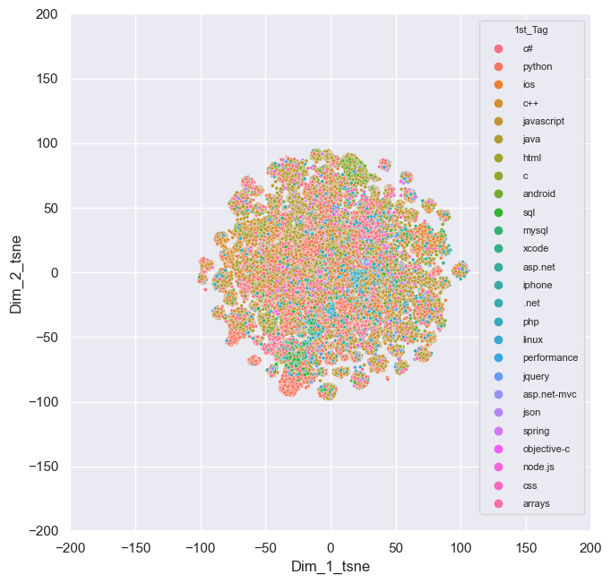

```python
fig = plt.figure(figsize=(7.5, 7.5))
sns.scatterplot(data=tsne_Y_df,
                x='Dim_1_tsne',
                y='Dim_2_tsne',
                hue='1st_Tag',
                s=8)
plt.xlim(-200, 200)
plt.ylim(-200, 200)
plt.setp(plt.gca().get_legend().get_texts(), fontsize='8')  # for legend text
plt.setp(plt.gca().get_legend().get_title(), fontsize='8')  # for legend titl
plt.show()
```

## 3. Test example

```python
# Load the stop_words
stop_w = joblib.load('data/stop_w.pkl')


# Function that take the title and body of a question and perform
# filtering, tokenization, lemmatization or stemming
def filter_tokenize_lem_stem(question_title, question_body):

    start = time.time()

    # Creating a varaible containing both the title and body
    question_title_body = question_title + ' ' + question_body

    # lower case the texts
    question_title_body = ' '.join([x.lower().replace('\n', ' ') for x in question_title_body.split()])

    # Function that will be used for removing the a href links and code tags
    def href_code_removing(x):
        BS = BeautifulSoup(x, 'lxml')
        for link in BS.find_all(['a', 'code', 'blockquote']):
            link.decompose()
        return BS.get_text()

    question_title_body_filt = ' '.join([href_code_removing(x) for x in question_title_body.split()])


    # Removing the links without a href in body and title
    question_title_body_filt = re.sub(r'http\S+', '', question_title_body, flags=re.MULTILINE)
    # Remove English contractions
    question_title_body_filt = re.sub("\'\w+", '', question_title_body_filt, flags=re.MULTILINE)
    # Remove adverbs (ly)
    question_title_body_filt = re.sub(r"\w+ly\b", '', question_title_body_filt, flags=re.MULTILINE)
    # Remove string of pure float numbers and remove . at the end of string
    question_title_body_filt = re.sub("((?<=[a-zA-Z:])+\.+?)|((?<=[\s])+?(\d*\.*)*)", ' ',
                                      question_title_body_filt, flags=re.MULTILINE)


    def start_end_char_clean(texts):
        # Removing all folder link like c:\ or c:/ etc
        c = set(word for x in texts for word in x
                if ((word.startswith("a:") or word.startswith("b:")
                     or word.startswith("c:") or word.startswith("d:")
                     or word.startswith("e:") or word.startswith("f:")
                     or word.startswith("g:") or word.startswith("h:")
                     or word.startswith("file:")
                     or word.startswith(":\\") or word.startswith(":/")
                     or word.startswith("\\") or word.endswith("\\")
                     or word.startswith("/") or word.endswith("/")
                     or word.startswith("./") or word.endswith("/.")
                     or word.startswith("<") or word.endswith(">")
                     or word.startswith("[") or word.endswith("]")
                     or word.startswith("{") or word.endswith("}")
                     or word.startswith("-") or word.endswith("-")
                     or word.startswith("+") or word.startswith("$"))))
        texts = ' '.join(y for y in texts.split() if y not in c)
        return texts

    question_title_body_filt = start_end_char_clean(question_title_body_filt)


    def tokenizer_fct(sentence) :
        sentence_clean = sentence.replace('---', '').replace('--', '')\
                                 .replace('- ', ' ').replace(' -', ' ')\
                                 .replace('...', '').replace('..', '')\
                                 .replace('. ', ' ')\
                                 .replace('_ ', ' ').replace(' _', ' ')\
                                 .replace(' &', ' ').replace('& ', ' ')\
                                 .replace('^', ' ')\
                                 .replace('?', '').replace('!', '')\
                                 .replace(';', ' ').replace(',', ' ')\
                                 .replace("'", ' ').replace('"', ' ')\
                                 .replace("’", ' ').replace('=', ' ')\
                                 .replace(')', ' ').replace('(', ' ')\
                                 .replace('|', ' ')\
                                 .replace('% ', ' ').replace(' %', ' ')\
                                 .replace(' #', ' ').replace('@', ' ')\
                                 .replace('*', ' ')\
                                 .replace('`', ' ').replace('~', ' ')
        tokenizer = RegexpTokenizer(r'\S+')
        word_tokens = tokenizer.tokenize(sentence_clean)
        return word_tokens


    # Stop word filtering
    def stop_word_filter_fct(list_words) :
        word_tokens = tokenizer_fct(list_words)
        # Removing all digits and stop words
        filtered_w = [w for w in word_tokens if (not w.isdigit() and not w in stop_w)]
        return filtered_w


    # Adjective and adverbe filtering
    def adj_adv_word_filter_fct(list_words) :
        word_tokens = stop_word_filter_fct(list_words)
        # Tags of adjective and adverbs
        adj_adv_tags = ['JJR', 'JJS', 'RB', 'RBR', 'RBS', 'WRB']
        # Tagging the words
        tags = dict(pos_tag(word_tokens))
        # Selecting the words tagged adjective and adverbs and not in tags list
        adj_adv_words = [word for word,pos in tags.items() if (pos in adj_adv_tags)]
        # Removing those words
        filtered_w = ' '.join([w for w in word_tokens if not w in adj_adv_words])
        return filtered_w


    print('Text after filtering, and tokenizing:\n{}\n'.format(adj_adv_word_filter_fct(question_title_body_filt)))


    # Lemmatizer
    def lem_fct(list_words) :
        list_words = adj_adv_word_filter_fct(list_words)
        lemmatizer = WordNetLemmatizer()
        lem_w = [lemmatizer.lemmatize(w) for w in list_words.split()]
        final_w = ' '.join(lem_w)
        return final_w


    # Stemmer
    def stem_fct(list_words) :
        list_words = adj_adv_word_filter_fct(list_words)
        stemmer = PorterStemmer()
        stem_w = [stemmer.stem(w) for w in list_words.split()]
        final_w = ' '.join(stem_w)
        return final_w

    question_title_body_filt_lem = lem_fct(question_title_body_filt)
    question_title_body_filt_stem = stem_fct(question_title_body_filt)

    question_title_body_filt_lem = start_end_char_clean(question_title_body_filt_lem)
    question_title_body_filt_stem = start_end_char_clean(question_title_body_filt_stem)


    def final_clean(sentence):
        sentence = sentence.replace(':', '')\
                           .replace('<','').replace('>','')\
                           .replace('[','').replace(']','')\
                           .replace('{','').replace('}','')
        sentence = ' '.join([w for w in sentence.split(' ') if ((len(w) > 2 and not w.isdigit()))])
        return sentence

    question_title_body_filt_lem = final_clean(question_title_body_filt_lem)
    question_title_body_filt_stem = final_clean(question_title_body_filt_stem)

    # Remove the left over string of pure float numbers
    question_title_body_filt_lem = re.sub("((?<=[\s])+?(\d*\.*)*)", '',
                                          question_title_body_filt_lem,
                                          flags=re.MULTILINE)
    question_title_body_filt_stem = re.sub("((?<=[\s])+?(\d*\.*)*)", '',
                                           question_title_body_filt_stem,
                                           flags=re.MULTILINE)

    stop = time.time()
    print('Processing time: {}s\n'.format(np.around((stop-start), 2)))
    print('Text after filtering, tokenizing, and lemmatization:\n{}\n'.format(question_title_body_filt_lem))
    print('Text after filtering, tokenizing, and stemming:\n{}'.format(question_title_body_filt_stem))

    return question_title_body_filt_lem, question_title_body_filt_stem
```

```python
question_title = input('Please enter the title of your question: ')
question_body = input('Please enter the body of your question: ')
```

```
Please enter the title of your question: How to do feature extraction from a question in python using neural-network?
Please enter the body of your question: I would like to extract features using neural-network in python.\ I've already applied supervised and unsupervised machine-learning algorithms, e.g, USE with KNN and TF-IDF with NMF.\ The end goal is to compare the neural-network results with the other already…
```

```python
question_title_body_filt_lem, question_title_body_filt_stem = filter_tokenize_lem_stem(question_title, question_body)
```

```
Text after filtering, and tokenizing:
feature extraction python neural-network extract features neural-network python applied supervised unsupervised machine-learning algorithms e g knn tf-idf nmf end goal compare neural-network results applied machine-learning algorithms

Processing time: 0.04s

Text after filtering, tokenizing, and lemmatization:
feature extraction python neural-network extract feature neural-network python applied supervised unsupervised machine-learning algorithm knn tf-idf nmf end goal compare neural-network result applied machine-learning algorithm

Text after filtering, tokenizing, and stemming:
featur extract python neural-network extract featur neural-network python appli supervis unsupervis machine-learn algorithm knn tf-idf nmf end goal compar neural-network result appli machine-learn algorithm
```

## 4. Final conclusion

- The example given in Sec.3 show how well the filtering is done on a given text.
- Even so that the stemmer leads to smaller vocabulary, I'm going to use lemmatizer during the modelisation because stemmer can leads to incorrect meanings and spelling of some words.
- We saw that the title is better suited to extract key-words than the body. However, there are lot of questions title with fewer words than the number of tags (all questions have >=5 tags) which can be problematic to the supervised learning modelisation. Therefore, we will use the title_body during the supervised learning modelisation.

## 5. Extracting the data

```python
column_list = ['Title', 'Body', 'Tags', 'Tags_30', 'length_Tags_30',
               'Title_filt_lem_bitri', 'length_Title_filt_lem_bitri',
               'Title_filt_stem_bitri', 'length_Title_filt_stem_bitri',
               'Body_filt_lem_bitri', 'length_Body_filt_lem_bitri',
               'Body_filt_stem_bitri', 'length_Body_filt_stem_bitri',
               'Title_Body_filt_lem_bitri', 'length_Title_Body_filt_lem_bitri',
               'Title_Body_filt_stem_bitri', 'length_Title_Body_filt_stem_bitri']
df_description(SO_questions_df[column_list])
```

|  | Title | Body | Tags | Tags_30 | length_Tags_30 | Title_filt_lem_bitri | length_Title_filt_lem_bitri | Title_filt_stem_bitri | length_Title_filt_stem_bitri | Body_filt_lem_bitri | length_Body_filt_lem_bitri | Body_filt_stem_bitri | length_Body_filt_stem_bitri | Title_Body_filt_lem_bitri | length_Title_Body_filt_lem_bitri | Title_Body_filt_stem_bitri | length_Title_Body_filt_stem_bitri |
| --- | --- | --- | --- | --- | --- | --- | --- | --- | --- | --- | --- | --- | --- | --- | --- | --- | --- |
| type | object | object | object | object | int64 | object | int64 | object | int64 | object | int64 | object | int64 | object | int64 | object | int64 |
| number null | 0.0 | 0.0 | 0.0 | 0.0 | 0.0 | 0.0 | 0.0 | 0.0 | 0.0 | 0.0 | 0.0 | 0.0 | 0.0 | 0.0 | 0.0 | 0.0 | 0.0 |
| percentage null | 0.0 | 0.0 | 0.0 | 0.0 | 0.0 | 0.0 | 0.0 | 0.0 | 0.0 | 0.0 | 0.0 | 0.0 | 0.0 | 0.0 | 0.0 | 0.0 | 0.0 |
| count | 114468 | 114468 | 114468 | 114468 | 114468.0 | 114468 | 114468.0 | 114468 | 114468.0 | 114468 | 114468.0 | 114468 | 114468.0 | 114468 | 114468.0 | 114468 | 114468.0 |
| unique | 114467 | 114468 | 103970 | 103970 | NaN | 113008 | NaN | 112914 | NaN | 114467 | NaN | 114467 | NaN | 114468 | NaN | 114468 | NaN |
| top | Pointcut matching methods with annotated param... | <p>How can I display the Wait/Busy Cursor (usu... | javascript jquery html css twitter-bootstrap | javascript jquery html css twitter-bootstrap | NaN | difference | NaN | differ | NaN | error code | NaN | error code | NaN | cursor turn wait cursor display cursor user le... | NaN | cursor turn wait cursor display cursor user le... | NaN |
| freq | 2 | 1 | 162 | 162 | NaN | 59 | NaN | 59 | NaN | 2 | NaN | 2 | NaN | 1 | NaN | 1 | NaN |
| mean | NaN | NaN | NaN | NaN | 5.000009 | NaN | 5.027309 | NaN | 5.057116 | NaN | 41.746139 | NaN | 42.011497 | NaN | 46.771403 | NaN | 47.070238 |
| std | NaN | NaN | NaN | NaN | 0.002956 | NaN | 1.929413 | NaN | 1.926594 | NaN | 35.352963 | NaN | 35.694649 | NaN | 35.651852 | NaN | 36.028577 |
| min | NaN | NaN | NaN | NaN | 5.0 | NaN | 1.0 | NaN | 1.0 | NaN | 1.0 | NaN | 1.0 | NaN | 7.0 | NaN | 8.0 |
| 25% | NaN | NaN | NaN | NaN | 5.0 | NaN | 4.0 | NaN | 4.0 | NaN | 20.0 | NaN | 20.0 | NaN | 25.0 | NaN | 25.0 |
| 50% | NaN | NaN | NaN | NaN | 5.0 | NaN | 5.0 | NaN | 5.0 | NaN | 32.0 | NaN | 32.0 | NaN | 37.0 | NaN | 38.0 |
| 75% | NaN | NaN | NaN | NaN | 5.0 | NaN | 6.0 | NaN | 6.0 | NaN | 52.0 | NaN | 52.0 | NaN | 57.0 | NaN | 58.0 |
| max | NaN | NaN | NaN | NaN | 6.0 | NaN | 18.0 | NaN | 18.0 | NaN | 1582.0 | NaN | 1582.0 | NaN | 1586.0 | NaN | 1586.0 |

```python
# Resetting the index before extraction
SO_questions_df = SO_questions_df.reset_index(drop=True)

# Extraction dataset without bigram and trigram
SO_questions_df[['Tags_30',
                 'Title_filt_lem', 'Title_filt_stem',
                 'Body_filt_lem', 'Body_filt_stem',
                 'Title_Body_filt_lem',
                 'Title_Body_filt_stem']].to_csv('data/SO_questions_cleaned_30.csv',
                                                 sep='\t', index=False)

# Extraction dataset with bigram and trigram
SO_questions_df[['Tags_30',
                 'Title_filt_lem_bitri', 'Title_filt_stem_bitri',
                 'Body_filt_lem_bitri', 'Body_filt_stem_bitri',
                 'Title_Body_filt_lem_bitri',
                 'Title_Body_filt_stem_bitri']].to_csv('data/SO_questions_cleaned_30_bitri.csv',
                                                       sep='\t', index=False)
```